# Homework 3

## Data for this homework

This homework is a continuation of Lab 3, where we made a function to draw Manhattan plots. Now we’ll look at some of the actual genotype and phenotype data that was used for that same genome-wide association analysis.

To save space and speed up data loading, the genotypes are saved in a .RData file called “Msi_genotypes.RData”. We can import it with `load`.

```r
load("Msi_genotypes.RData")
```

The data format is something called a matrix, which we haven’t discussed in class yet, but it is two-dimensional like a data frame. Matrices are a bit more efficient than data frames when all data are the same type, like genotypes at thousands of SNP markers. To get the genotypes for all individuals at just one marker, index it like this:

```r
msi_gen[,"PstI-TP25701"]
```

Homozygotes for either allele are coded as -1 and 1, respectively. Heterozygotes are coded as 0. Missing data were imputed based on relatedness, and generally are intermediate values representing uncertainty of genotypes.

There is also a CSV with BLUPs (best linear unbiased predictors) of the yield and height phenotypes, as well as assignment of each individual to a genetic group (DAPC_group).

```r
phen <- read.csv("Msi_groups_and_phenotypes.csv")
head(phen)
```

```
##          Sample_name        DAPC_group Yield_BLUP Height_BLUP
## 1              Akeno           S Japan   7.072330   2499.3635
## 2 CANE9233-US47-0011 SE China/tropical  -7.177237   -663.6775
## 3      DC-2010-001-A    US naturalized         NA          NA
## 4      DC-2010-001-E    US naturalized  -2.177541   -580.0359
## 5              Gunma           S Japan   6.771465   1873.1677
## 6       IGR-2011-001        Ornamental         NA          NA
```

For simplicity, the two files have accessions listed in the same order.

## Inspecting significantly associated SNPs

Once you have identified a significant SNP (you should have seen some that were high on the Manhattan plot in the lab; they are also at the top of each GWAS spreadsheet), you might have some questions about why it was significant, and how useful it could be in marker assisted selection. Was the minor allele (the allele that was less common in the population) associated with an increase or decrease in the phenotype? Was a different effect seen in heterozygotes versus homozygotes? What genetic groups had the minor allele? How many individuals?

We can answer all of these questions by drawing a scatter plot of phenotype versus genotype, particularly if we color by genetic group. Here’s an example using ggplot.

```r
library(ggplot2)
```

The code for the graph below will be posted in the answer key.

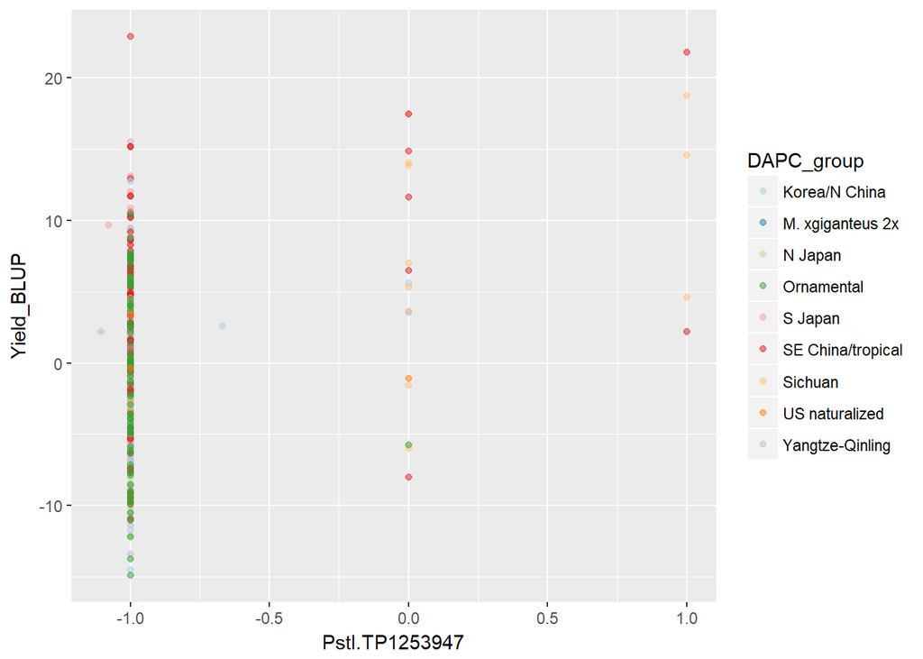

```r
phen$PstI.TP1253947 <- msi_gen[,"PstI-TP1253947"]
ggplot(phen, aes(x = PstI.TP1253947, y = Yield_BLUP, col = DAPC_group)) +
  geom_point(alpha = 0.5) +
  scale_color_brewer(type = "qual", palette = "Paired")
```

From this we can see that the minor allele tends to show up in the SE China/tropical and Sichuan groups, that it is associated with higher yield, and that the effect seems to be additive, with homozygotes having higher yields than heterozygotes.

Maybe we want to inspect one group at a time. dplyr could be useful for this.

```r
library(dplyr)
```

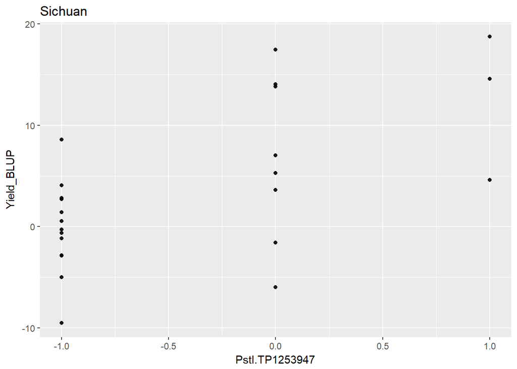

```r
filter(phen, DAPC_group == "Sichuan") %>%
  ggplot(aes(x = PstI.TP1253947, y = Yield_BLUP)) +
  geom_point(alpha = 0.9) +
  ggtitle("Sichuan")
```

Try recreating these two plots, using either ggplot or the base graphics system. If you are using ggplot, you might add genotypes at SNPs of interest to your phenotype data frame for ease of plotting.

Once you have it figured out, explore some of the other SNPs. Are alleles for high yield tending to come from the same genetic groups or different ones? What about height?

After performing this task repeatedly, you may find yourself copying and pasting code, and just changing a few things each time. Try making a function to help automate what you want to do.

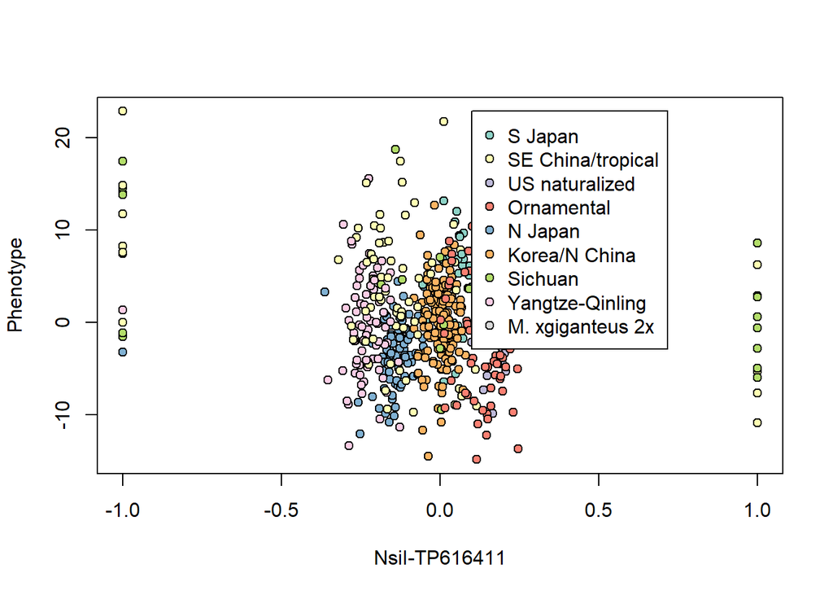

```r
# an example function using the base graphics system.
# Plot genotype on the x-axis, phenotype on the y-axis, and color by genetic
# group.  Have an option to filter by genetic group
# genotypes is a matrix of genotypes, with markers in columns
# marker is the marker name
# phenotypes is a vector of phenotype values
# groups is a vector of group ids
gen_vs_phen <- function(genotypes, phenotypes, groups, marker,
                        group.subset = unique(groups)){
  require(RColorBrewer)
  # how many genetic groups are there
  ngrp <- length(group.subset)
  # get a color palette for genetic groups
  mypal <- brewer.pal(ngrp, "Set3")
  # name it for indexing (we haven't done this in class quite yet)
  names(mypal) <- group.subset
  # get subset of observations to plot
  subset <- groups %in% group.subset
  # draw plot
  plot(genotypes[subset,marker], phenotypes[subset],
       xlab = marker, ylab = "Phenotype",
       bg = mypal[as.character(groups[subset])], pch = 21,
       xlim = c(-1,1))
  # figure out which corner would be best for legend
  meanphen <- mean(phenotypes[subset], na.rm = TRUE)
  topleft <- sum(genotypes[subset,marker] < 0 & phenotypes[subset] > meanphen, na.rm = TRUE)
  topright <- sum(genotypes[subset,marker] > 0 & phenotypes[subset] > meanphen, na.rm = TRUE)
  bottomleft <- sum(genotypes[subset,marker] < 0 & phenotypes[subset] < meanphen, na.rm = TRUE)
  bottomright <- sum(genotypes[subset,marker] > 0 & phenotypes[subset] < meanphen, na.rm = TRUE)
  corners <- c(topleft, topright, bottomleft, bottomright)
  if(min(corners) %in% c(topleft, bottomleft)){
    legX <- -0.9
    legY <- max(phenotypes[subset], na.rm = TRUE)
  }
  if(min(corners) %in% c(topright, bottomright)){
    legX <- 0.1
    legY <- max(phenotypes[subset], na.rm = TRUE)
  }
  # make legend
  legend(legX, legY, legend = group.subset, pt.bg = mypal, pch = 21)
}

# draw plots
gen_vs_phen(msi_gen, phen$Yield_BLUP, phen$DAPC_group, "NsiI-TP616411")
```

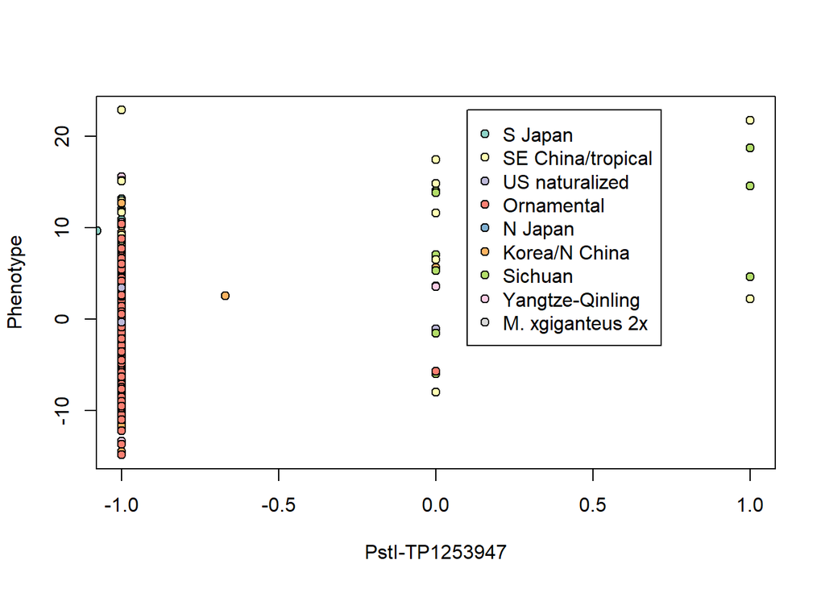

```r
gen_vs_phen(msi_gen, phen$Yield_BLUP, phen$DAPC_group, "PstI-TP1253947")
```

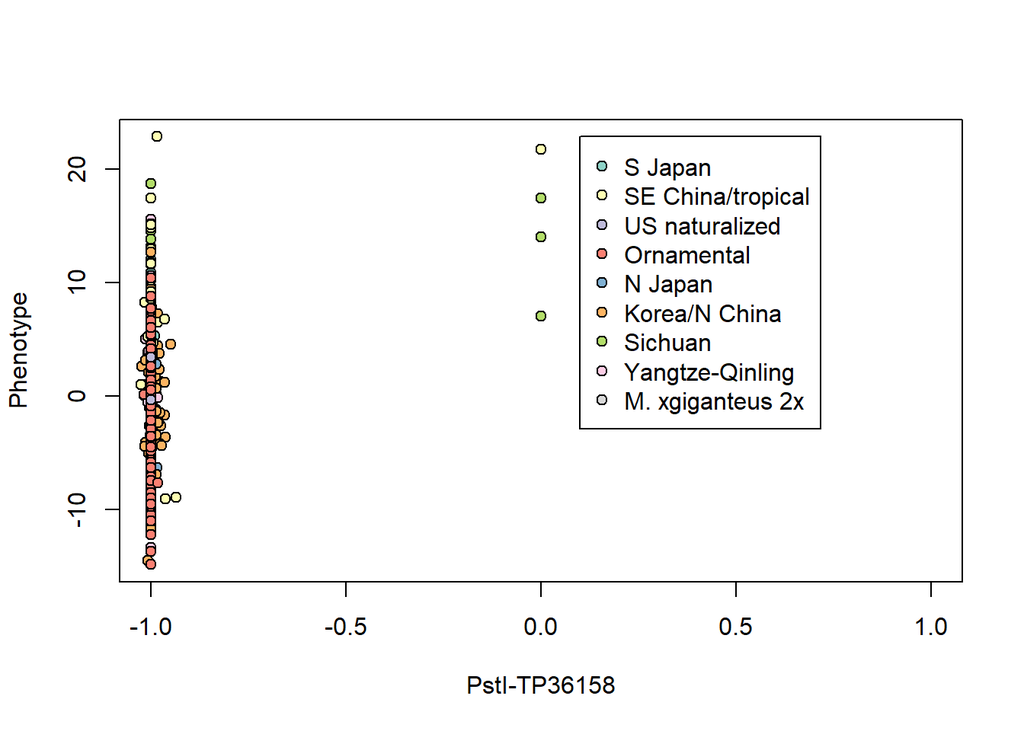

```r
gen_vs_phen(msi_gen, phen$Yield_BLUP, phen$DAPC_group, "PstI-TP36158")
```

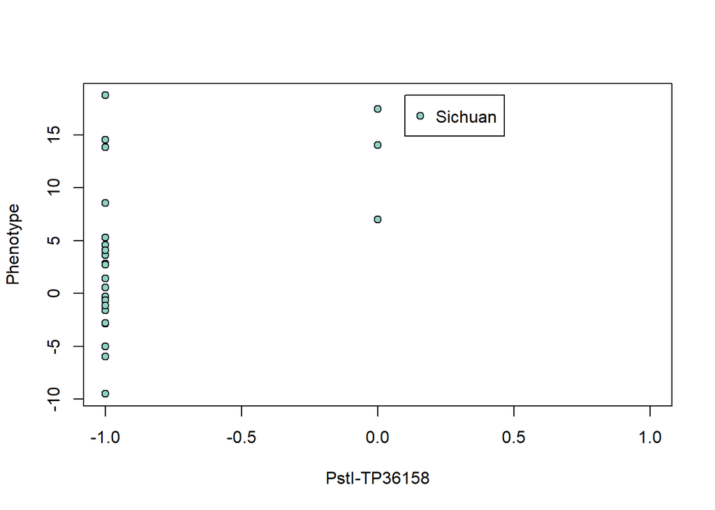

```r
gen_vs_phen(msi_gen, phen$Yield_BLUP, phen$DAPC_group, "PstI-TP36158",
            group.subset = "Sichuan")
```

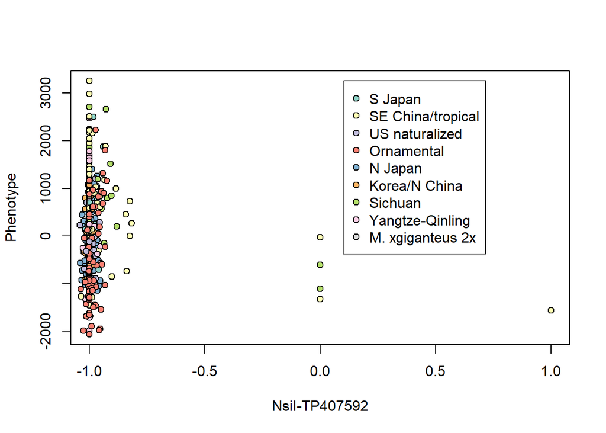

```r
gen_vs_phen(msi_gen, phen$Height_BLUP, phen$DAPC_group, "NsiI-TP407592")
```

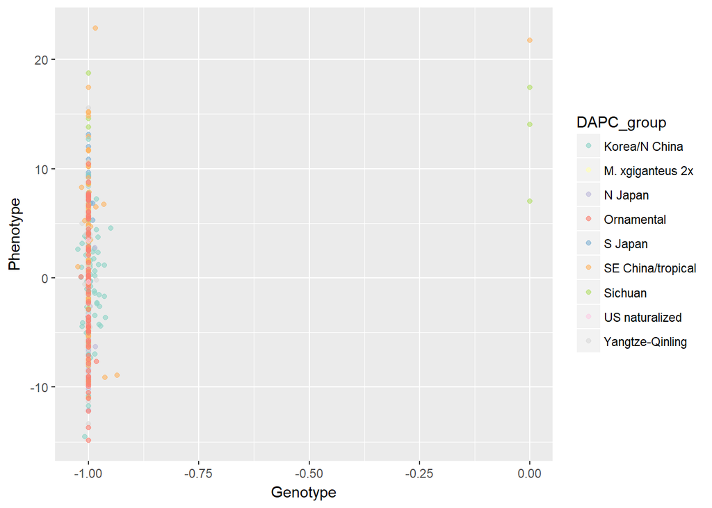

```r
# Many of the significant SNPs are variable within the SE China/tropical and
# Sichuan groups.

# version with ggplot
gen_vs_phen2 <- function(genotypes, phenotypes, groups, marker,
                        group.subset = unique(groups)){
  require(ggplot2)
  # subset of individuals to plot
  subset <- groups %in% group.subset
  # set up a data frame for ggplot
  df <- data.frame(DAPC_group = groups[subset],
                   Phenotype = phenotypes[subset],
                   Genotype = genotypes[subset,marker])

  # draw plot
  ggplot(df, aes(x = Genotype, y = Phenotype, col = DAPC_group)) +
    geom_point(alpha = 0.6) +
    scale_color_brewer(type = "qual", palette = "Set3")
}

# draw plots
gen_vs_phen2(msi_gen, phen$Yield_BLUP, phen$DAPC_group, "PstI-TP36158")
```